# Inference on biological sequence data

Mini-project of BIO-369: Randomness and information in biological data, Spring 2024@EPFL

```python
# import necessary packages
import numpy as np
import matplotlib.pyplot as plt
from math import log as ln
from math import exp
```

## 1. Statistical dependence in protein sequence data

#### a)

```python
# load MALGMALK1.fasta
def read_fasta(file_path):
    sequences = []
    with open(file_path, 'r') as file:
        sequence = ''
        for line in file:
            line = line.strip()
            if not line.startswith('>'):
                sequence += line
            elif sequence:
                sequences.append(sequence)
                sequence = ''
        if sequence:
            sequences.append(sequence)
    return sequences

sequences = read_fasta('data/MALGMALK1.fasta')
```

```python
# transform strings into a Numpy array
def map_char_to_int(c):
    char_mapping = {
        'A': 0, 'C': 1, 'D': 2, 'E': 3, 'F': 4,
        'G': 5, 'H': 6, 'I': 7, 'K': 8, 'L': 9,
        'M': 10, 'N': 11, 'P': 12, 'Q': 13, 'R': 14,
        'S': 15, 'T': 16, 'V': 17, 'W': 18, 'Y': 19,
        '-': 20
    }
    return char_mapping.get(c, -1)

def map_str_to_array(string):
    string_int = []
    for c in string:
        c_int = map_char_to_int(c)
        string_int.append(c_int)
    return string_int

def map_str_to_np(sequences):
    sequences_int = []
    for sequence in sequences:
        sequence_int = map_str_to_array(sequence)
        sequences_int.append(sequence_int)
    return np.array(sequences_int)

sequences_np = map_str_to_np(sequences)
```

```python
# show the result
print("Matrix shape:", sequences_np.shape)
print(sequences_np)
```

```
Matrix shape: (5004, 319)
[[20 10 18 ...  3 12  9]
 [ 0 14  2 ...  3 12  9]
 [16  8  4 ...  3 12  4]
 ...
 [16  8  4 ...  3 12  9]
 [ 9 11 14 ...  3 12 10]
 [11 13  8 ...  3 12  9]]
```

#### b)

```python
# calculate the entropy
def calc_entropy(column):
    # frequency of each amino acid
    aa_counts = np.bincount(column, minlength=21)
    aa_probs = aa_counts / np.sum(aa_counts)
    # entropy
    entropy = -np.sum(aa_probs * np.log2(aa_probs + 1e-10))
    return entropy

column_entropies = np.apply_along_axis(calc_entropy, axis=0, arr=sequences_np)
```

```python
# calculate the mean entropy
def calc_mean_entropy(sequences_np):
    MALG_sites = sequences_np[:, :177]  # MALG
    MALK_sites = sequences_np[:, 177:]  # MALK
    MALG_entropies = np.apply_along_axis(calc_entropy, axis=0, arr=MALG_sites)
    MALK_entropies = np.apply_along_axis(calc_entropy, axis=0, arr=MALK_sites)
    mean_malg_entropy = np.mean(MALG_entropies)
    mean_malk_entropy = np.mean(MALK_entropies)
    return mean_malg_entropy, mean_malk_entropy

MALG_mean_entropy, MALK_mean_entropy = calc_mean_entropy(sequences_np)
```

```python
# show the result
print("Mean entropy over MALG sites:", MALG_mean_entropy)
print("Mean entropy over MALK sites:", MALK_mean_entropy)

print("\nEntropy of each column:")
print(column_entropies)
```

```
Mean entropy over MALG sites: 2.949385690726502
Mean entropy over MALK sites: 1.6972734976666888

Entropy of each column:
[3.22810168 3.39340922 3.96022235 3.53541837 3.2295838  2.96922021
 3.09762563 2.81081023 3.82439    3.20375356 2.71628834 3.51195005
 3.6981833  2.93107984 2.99382101 3.2807548  2.77380658 2.42780064
 3.52694079 3.07624342 2.96312983 1.55912853 3.66969194 3.23170267
 2.51203669 3.45076077 3.03438138 3.31848087 3.34290835 3.16648974
 3.46116504 3.29942668 2.8666346  2.77709055 3.20002731 3.26064084
 3.29914587 3.27915413 4.13526478 4.1149925  3.66830615 3.84152469
 3.97051025 2.8699264  3.76806877 3.83668969 3.0221302  4.02175578
 3.5354819  2.77570438 2.83559537 2.90922858 2.26325948 2.96842443
 3.64429578 2.96693082 3.18501138 3.69331711 3.62210752 2.97407218
 1.42844789 2.24075689 3.04616206 2.61952173 2.93751403 3.11392981
 2.61068138 3.65280489 2.95408665 3.12977429 2.16092604 3.59552943
 3.30159399 2.41224043 2.13125753 3.72843844 2.91469703 2.21387178
 2.98249577 1.76725945 0.54425363 0.83057555 3.3599301  2.91178106
 1.66309153 0.57170959 1.25274454 2.49463496 3.19155939 2.88208798
 2.73337778 3.16006708 1.59831993 2.92497611 3.24437205 1.20520619
 2.65149335 1.93626322 0.06887772 2.37039949 2.74106152 3.22119908
 2.19444542 2.44666071 2.07317592 2.75548946 2.8776258  2.4840622
 3.16193937 2.70701099 2.33439963 3.07543087 2.06284526 2.64560762
 3.84820661 2.67969981 2.74925136 2.80964043 2.83347721 1.80101399
 3.49260606 3.43677967 2.66932908 3.52742207 2.61589726 2.40839957
 2.85880333 2.99729722 3.40304228 3.54409992 3.78926962 3.52148755
 3.69781292 3.4851359  3.29809355 3.57413158 3.89621883 3.63990825
 3.59339157 3.92182193 3.87866082 3.75246573 3.78779306 3.75113208
 3.67042378 3.9550144  3.80218116 3.88938342 2.60272845 2.70046381
 3.33392047 3.63504371 3.81776803 2.96175736 2.4959654  2.71570396
 3.10448975 3.07270004 2.8403084  3.24924264 3.0436828  2.85500183
 2.70765959 3.1537037  3.17256402 2.78006327 2.87603241 3.17731539
 3.09936689 2.91996307 2.61539721 2.44911999 2.02281185 2.26116892
 1.44134015 1.23364454 1.30038521 2.83865846 2.77207893 2.17937895
 2.17358789 1.40766243 2.94279144 1.43347148 3.46126212 3.03617279
 0.85524057 1.37887047 1.70908969 2.64271881 2.33356305 1.57203361
 1.12728118 0.02432822 0.77274723 0.10128638 0.04427537 0.88516726
 0.13718698 0.02432822 1.0230369  0.21335145 2.03134657 0.23985714
 1.11124573 2.20969665 1.3453693  0.52493001 0.00508844 1.12042917
 1.53338479 3.56314383 2.41624675 2.01442003 2.81978694 0.01057633
 3.24665644 1.50987366 3.70208986 1.95415708 2.48650827 1.84519352
 2.97926378 2.70687165 2.19488674 2.48313557 3.39714306 2.62100224
 2.39283751 1.46731808 3.38176691 2.882824   0.02471853 2.84521666
 1.84354823 1.9744747  1.80367845 0.65294357 0.20658665 0.01989855
 2.16883612 0.50457891 0.45115026 0.32596012 1.18071166 0.7089251
 0.83853938 1.04867419 1.54355843 0.7640241  2.97582982 2.13371862
 0.00548812 1.87009879 1.59445851 1.0942415  1.17039695 2.308585
 3.5154636  3.21972693 2.50049019 3.20539144 2.78277254 2.53961215
 3.21438871 3.1582542  2.19455622 1.72751334 3.61049934 2.85226317
 2.46859795 2.10221327 2.88488175 3.05232398 1.68971525 3.02705792
 1.62981449 3.53816361 3.43396384 2.88534712 2.5977192  3.16000529
 1.76721955 3.03224002 1.89312845 1.23549239 0.98583066 1.15988626
 0.92754236 3.1852811  2.12570022 0.50542015 0.12156459 0.18337249
 0.13435921 0.29871073 1.49681108 0.02274009 0.12554193 0.54830783
 0.20434846 1.66133417 1.07435944 0.03994505 0.94305844 1.47076849
 1.27457119 3.17481179 2.74342001 0.63518106 3.06951242 1.71856448
 1.63023361 0.26592778 1.46066894 0.01139979 0.02855241 0.35968427
 1.16114946]
```

According to the calculations, the mean entropy over MALG sites (2.949) is higher than that over MALK sites (1.697).

These findings suggest greater variability or uncertainty at MALG sites, while MALK sites appear to be more conserved or consistent.

Moreover, it implies that MALG has been subject to a higher degree of mutation throughout evolution, while MALK is inclined towards maintaining functional and structural stability.

#### c)

```python
# calculate the mutual information matrix
def calc_mutual_info(col_1, col_2):
    # calculate joint distribution
    joint_distribution = np.zeros((21, 21))
    for k in range(len(col_1)):
        joint_distribution[col_1[k], col_2[k]] += 1
    joint_distribution /= len(col_1)

    # calculate marginal distribution
    marginal_1 = np.sum(joint_distribution, axis=1)
    marginal_2 = np.sum(joint_distribution, axis=0)

    # calculate mutual information
    mutual_info = 0
    for i in range(21):
        for j in range(21):
            if joint_distribution[i, j] > 0:
                mutual_info += joint_distribution[i, j] * np.log2(joint_distribution[i, j] / (marginal_1[i] * marginal_2[j]))
    return mutual_info


def calc_mutual_info_matrix(sequences_np):
    MALG_sites = sequences_np[:, :177]  # MALG
    MALK_sites = sequences_np[:, 177:]  # MALK
    mi_matrix = np.zeros((MALG_sites.shape[1], MALK_sites.shape[1]))
    for i in range(MALG_sites.shape[1]):
        for j in range(MALK_sites.shape[1]):
            mi_matrix[i, j] = calc_mutual_info(MALG_sites[:, i], MALK_sites[:, j])
    return mi_matrix


mutual_info_matrix = calc_mutual_info_matrix(sequences_np)
```

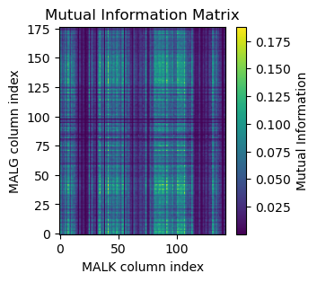

```
Within most fragments, the mutual information values between MALG and MALK were low, representing a low degree of dependence between the two.
```

```python
# plot the resulting matrix
plt.figure(figsize=(3, 3))
plt.imshow(mutual_info_matrix, cmap='viridis', origin='lower')
plt.colorbar(label='Mutual Information')
plt.xlabel('MALK column index')
plt.ylabel('MALG column index')
plt.title('Mutual Information Matrix')
plt.show()

print("Within most fragments, the mutual information values between MALG and MALK were low, representing a low degree of dependence between the two.")
```

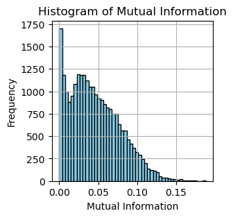

```python
# plot the histogram
plt.figure(figsize=(3, 3))
plt.hist(mutual_info_matrix.flatten(), bins=50, color='skyblue', edgecolor='black')
plt.xlabel('Mutual Information')
plt.ylabel('Frequency')
plt.title('Histogram of Mutual Information')
plt.grid(True)
plt.show()
```

#### d)

```python
# load MALGMALK2.fasta
sequences_2 = read_fasta('data/MALGMALK2.fasta')
sequences_np_2 = map_str_to_np(sequences_2)

# show the result
print("Matrix shape:", sequences_np_2.shape)
print(sequences_np_2)
```

```
Matrix shape: (5004, 319)
[[20 10 18 ...  3 12  9]
 [ 0 14  2 ...  3 12  9]
 [16  8  4 ...  3 12  4]
 ...
 [16  8  4 ...  3 12  4]
 [ 9 11 14 ...  3 12  9]
 [11 13  8 ...  3 12  9]]
```

```python
# calculate the entropy and the mean entropy
column_entropies_2 = np.apply_along_axis(calc_entropy, axis=0, arr=sequences_np_2)
MALG_mean_entropy_2, MALK_mean_entropy_2 = calc_mean_entropy(sequences_np_2)

# show the result
print("Mean entropy over MALG sites:", MALG_mean_entropy_2)
print("Mean entropy over MALK sites:", MALK_mean_entropy_2)
print("\nEntropy of each column:")
print(column_entropies_2)
```

```
Mean entropy over MALG sites: 2.949385690726502
Mean entropy over MALK sites: 1.6972734976666888

Entropy of each column:
[3.22810168 3.39340922 3.96022235 3.53541837 3.2295838  2.96922021
 3.09762563 2.81081023 3.82439    3.20375356 2.71628834 3.51195005
 3.6981833  2.93107984 2.99382101 3.2807548  2.77380658 2.42780064
 3.52694079 3.07624342 2.96312983 1.55912853 3.66969194 3.23170267
 2.51203669 3.45076077 3.03438138 3.31848087 3.34290835 3.16648974
 3.46116504 3.29942668 2.8666346  2.77709055 3.20002731 3.26064084
 3.29914587 3.27915413 4.13526478 4.1149925  3.66830615 3.84152469
 3.97051025 2.8699264  3.76806877 3.83668969 3.0221302  4.02175578
 3.5354819  2.77570438 2.83559537 2.90922858 2.26325948 2.96842443
 3.64429578 2.96693082 3.18501138 3.69331711 3.62210752 2.97407218
 1.42844789 2.24075689 3.04616206 2.61952173 2.93751403 3.11392981
 2.61068138 3.65280489 2.95408665 3.12977429 2.16092604 3.59552943
 3.30159399 2.41224043 2.13125753 3.72843844 2.91469703 2.21387178
 2.98249577 1.76725945 0.54425363 0.83057555 3.3599301  2.91178106
 1.66309153 0.57170959 1.25274454 2.49463496 3.19155939 2.88208798
 2.73337778 3.16006708 1.59831993 2.92497611 3.24437205 1.20520619
 2.65149335 1.93626322 0.06887772 2.37039949 2.74106152 3.22119908
 2.19444542 2.44666071 2.07317592 2.75548946 2.8776258  2.4840622
 3.16193937 2.70701099 2.33439963 3.07543087 2.06284526 2.64560762
 3.84820661 2.67969981 2.74925136 2.80964043 2.83347721 1.80101399
 3.49260606 3.43677967 2.66932908 3.52742207 2.61589726 2.40839957
 2.85880333 2.99729722 3.40304228 3.54409992 3.78926962 3.52148755
 3.69781292 3.4851359  3.29809355 3.57413158 3.89621883 3.63990825
 3.59339157 3.92182193 3.87866082 3.75246573 3.78779306 3.75113208
 3.67042378 3.9550144  3.80218116 3.88938342 2.60272845 2.70046381
 3.33392047 3.63504371 3.81776803 2.96175736 2.4959654  2.71570396
 3.10448975 3.07270004 2.8403084  3.24924264 3.0436828  2.85500183
 2.70765959 3.1537037  3.17256402 2.78006327 2.87603241 3.17731539
 3.09936689 2.91996307 2.61539721 2.44911999 2.02281185 2.26116892
 1.44134015 1.23364454 1.30038521 2.83865846 2.77207893 2.17937895
 2.17358789 1.40766243 2.94279144 1.43347148 3.46126212 3.03617279
 0.85524057 1.37887047 1.70908969 2.64271881 2.33356305 1.57203361
 1.12728118 0.02432822 0.77274723 0.10128638 0.04427537 0.88516726
 0.13718698 0.02432822 1.0230369  0.21335145 2.03134657 0.23985714
 1.11124573 2.20969665 1.3453693  0.52493001 0.00508844 1.12042917
 1.53338479 3.56314383 2.41624675 2.01442003 2.81978694 0.01057633
 3.24665644 1.50987366 3.70208986 1.95415708 2.48650827 1.84519352
 2.97926378 2.70687165 2.19488674 2.48313557 3.39714306 2.62100224
 2.39283751 1.46731808 3.38176691 2.882824   0.02471853 2.84521666
 1.84354823 1.9744747  1.80367845 0.65294357 0.20658665 0.01989855
 2.16883612 0.50457891 0.45115026 0.32596012 1.18071166 0.7089251
 0.83853938 1.04867419 1.54355843 0.7640241  2.97582982 2.13371862
 0.00548812 1.87009879 1.59445851 1.0942415  1.17039695 2.308585
 3.5154636  3.21972693 2.50049019 3.20539144 2.78277254 2.53961215
 3.21438871 3.1582542  2.19455622 1.72751334 3.61049934 2.85226317
 2.46859795 2.10221327 2.88488175 3.05232398 1.68971525 3.02705792
 1.62981449 3.53816361 3.43396384 2.88534712 2.5977192  3.16000529
 1.76721955 3.03224002 1.89312845 1.23549239 0.98583066 1.15988626
 0.92754236 3.1852811  2.12570022 0.50542015 0.12156459 0.18337249
 0.13435921 0.29871073 1.49681108 0.02274009 0.12554193 0.54830783
 0.20434846 1.66133417 1.07435944 0.03994505 0.94305844 1.47076849
 1.27457119 3.17481179 2.74342001 0.63518106 3.06951242 1.71856448
 1.63023361 0.26592778 1.46066894 0.01139979 0.02855241 0.35968427
 1.16114946]
```

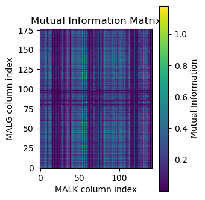

```
The distribution of mutual information between the different columns of MALG and MALG is evenly and the values are relatively high. It indicates that their homology is stronger.
```

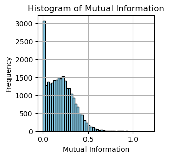

```python
# calculate the mutual information matrix
mutual_info_matrix_2 = calc_mutual_info_matrix(sequences_np_2)

# plot the resulting matrix
plt.figure(figsize=(3, 4))
plt.imshow(mutual_info_matrix_2, cmap='viridis', origin='lower')
plt.colorbar(label='Mutual Information')
plt.xlabel('MALK column index')
plt.ylabel('MALG column index')
plt.title('Mutual Information Matrix')
plt.show()

print("The distribution of mutual information between the different columns of MALG and MALG is evenly and the values are relatively high. It indicates that their homology is stronger.")

# plot the histogram
plt.figure(figsize=(3, 3))
plt.hist(mutual_info_matrix_2.flatten(), bins=50, color='skyblue', edgecolor='black')
plt.xlabel('Mutual Information')
plt.ylabel('Frequency')
plt.title('Histogram of Mutual Information')
plt.grid(True)
plt.show()
```

#### e)

```python
# caculate the mean of the mutual information
mean_mi = np.mean(mutual_info_matrix.flatten())
mean_mi_2 = np.mean(mutual_info_matrix_2.flatten())

print("Mean mutual information for MALGMALK1.fasta:", mean_mi)
print("Mean mutual information for MALGMALK2.fasta:", mean_mi_2)
```

```
Mean mutual information for MALGMALK1.fasta: 0.04606188406015038
Mean mutual information for MALGMALK2.fasta: 0.19845612975593496
```

The distribution of mutual information values of MALGMALK2.fasta is more uniform and generally higher compared to that of MALGMALK1.fasta.

The mean of the mutual information values of MALGMALK1.fasta is smaller than that of MALGMALK2.fasta, so:

1. MALGMALK1.fasta likely contains scrambled sequences.
2. MALGMALK2.fasta likely contains actual interacting partners.

#### f)

Extract different amounts of data (10, 100, 250, 500, 1000, 2500, 5000) from MALGMALK1.fasta and MALGMALK2.fasta, and use these subsets for calculation.

Conclusion:

1. As the data size increases, the mean values of entropy and mutual information approach the true values more closely.
2. The effect of finite-size is evident. When the data size is small, it may lead to less accurate estimates of entropy and mutual information.

```python
# use different sizes of dataset
sample_sizes = [10, 100, 250, 500, 1000, 2500, 5000]

# list to store the results
mean_entropy_MALG_f1, mean_entropy_MALK_f1 = [], []
mean_entropy_MALG_f2, mean_entropy_MALK_f2 = [], []
mean_mi_f1, mean_mi_f2 = [], []

# choose different sizes of dataset
for sample_size in sample_sizes:
    # generate the subsets
    sequences_subset_f1 = sequences_np[:sample_size]
    sequences_subset_f2 = sequences_np_2[:sample_size]

    # calculate mean entropy
    MALG_mean_entropy_f1, MALK_mean_entropy_f1 = calc_mean_entropy(sequences_subset_f1)
    MALG_mean_entropy_f2, MALK_mean_entropy_f2 = calc_mean_entropy(sequences_subset_f2)
    mean_entropy_MALG_f1.append(MALG_mean_entropy_f1)
    mean_entropy_MALK_f1.append(MALK_mean_entropy_f1)
    mean_entropy_MALG_f2.append(MALG_mean_entropy_f2)
    mean_entropy_MALK_f2.append(MALK_mean_entropy_f2)

    # calculate mean mutual information
    mutual_info_matrix_f1, mutual_info_matrix_f2 = calc_mutual_info_matrix(sequences_subset_f1), calc_mutual_info_matrix(sequences_subset_f2)
    mean_mi_f1.append(np.mean(mutual_info_matrix_f1))
    mean_mi_f2.append(np.mean(mutual_info_matrix_f2))
```

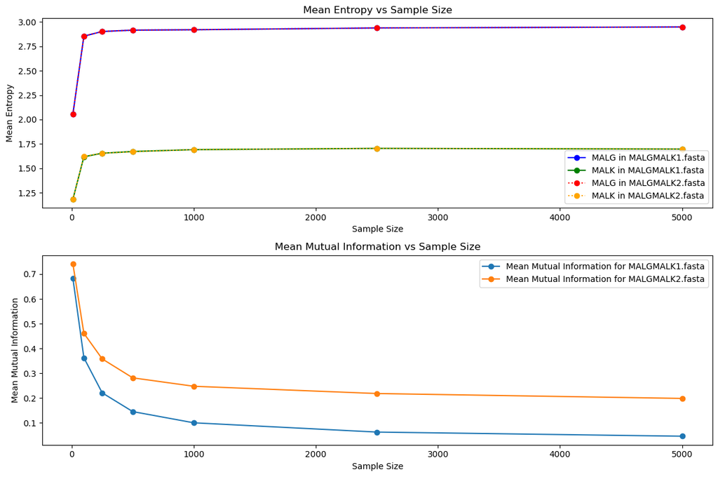

```python
# plot the results
plt.figure(figsize=(12, 8))

plt.subplot(2, 1, 1)
plt.plot(sample_sizes, mean_entropy_MALG_f1, marker='o', linestyle='-', color='blue', label='MALG in MALGMALK1.fasta')
plt.plot(sample_sizes, mean_entropy_MALK_f1, marker='o', linestyle='-', color='green', label='MALK in MALGMALK1.fasta')
plt.plot(sample_sizes, mean_entropy_MALG_f2, marker='o', linestyle=':', color='red', label='MALG in MALGMALK2.fasta')
plt.plot(sample_sizes, mean_entropy_MALK_f2, marker='o', linestyle=':', color='orange', label='MALK in MALGMALK2.fasta')
plt.xlabel('Sample Size')
plt.ylabel('Mean Entropy')
plt.title('Mean Entropy vs Sample Size')
plt.legend()

plt.xlabel('Sample Size')
plt.ylabel('Mean Entropy')
plt.title('Mean Entropy vs Sample Size')
plt.legend()

plt.subplot(2, 1, 2)
plt.plot(sample_sizes, mean_mi_f1, marker='o', label='Mean Mutual Information for MALGMALK1.fasta')
plt.plot(sample_sizes, mean_mi_f2, marker='o', label='Mean Mutual Information for MALGMALK2.fasta')
plt.xlabel('Sample Size')
plt.ylabel('Mean Mutual Information')
plt.title('Mean Mutual Information vs Sample Size')
plt.legend()

plt.tight_layout()
plt.show()
```

#### g)

1. MALG and MALK are involved in the glucose metabolism pathway,with MALG acting as an enzyme and MALK as a kinase. Their ability to interact specifically is due to their complementary structures.
2. Sites with high mutual information are more likely to be located close to their binding interface.
3. Similarities with the HK-RR case include both systems involve two-protein signal transduction, but they differ in their functions and where they operate within the cell.

#### h)

We can infer the correct pairs of partners based on these high mutual information site pairs:

1. Calculate the mutual information matrix for the scrambled MALG-MALK partners.
2. Identify site pairs with high mutual information values and consider them as potential correct partner pairs.
3. Combine these site pairs into partner pairs and form a candidate list of partner pairs.
4. Furtherly validate the correctness of these candidate partner pairs.

## 2. Maximum likelihood inference of phylogeny

#### a)

According to the description, the probability that one single site is different is $p(d)$ and the probability that it is the same is $1-3p(d)$. So the probability that any n sites among L differ between the two sequences is $$P(n|L, d) = \begin{pmatrix} L \\ n \end{pmatrix} \left[p(d)\right]^n \left[1-3p(d)\right]^{L-n}.$$It is consistent with the binomial distribution.

#### c)

```python
# load the data
def convert_to_numbers(sequences):
    conversion_dict = {'A': '0', 'C': '1', 'G': '2', 'T': '3'}
    converted_sequences = []
    for sequence in sequences:
        converted_sequence = [conversion_dict[base] for base in sequence]
        converted_sequences.append("".join(converted_sequence))
    return converted_sequences

sequences_BL = read_fasta('data/BetaLactamase.fasta')
sequences_BL_num = convert_to_numbers(sequences_BL)

print('sequence_0:', sequences_BL_num[0])
print('sequence_1:', sequences_BL_num[1])
print('sequence_2:', sequences_BL_num[2])
```

```
sequence_0: 201202031231202212301021231001002232211231212231011332032201…
sequence_1: 201122231011101221301021232102002132212231212232212232032201…
sequence_2: 201202121333211032321023011232002331133212212212103212132211…
```

```python
# calculate evolutionary distance
def calculate_evolutionary_distance(sequence1, sequence2):
    n_differences = sum(1 for base1, base2 in zip(sequence1, sequence2) if base1 != base2)
    L = len(sequence1)
    return -3/4 * ln(1 - 3/4 * n_differences / L)

d01 = calculate_evolutionary_distance(sequences_BL_num[0], sequences_BL_num[1])
d02 = calculate_evolutionary_distance(sequences_BL_num[0], sequences_BL_num[2])
d12 = calculate_evolutionary_distance(sequences_BL_num[1], sequences_BL_num[2])
```

```python
# show the results
print("Estimated evolutionary distance d01:", d01)
print("Estimated evolutionary distance d02:", d02)
print("Estimated evolutionary distance d12:", d12)
```

```
Estimated evolutionary distance d01: 0.21576155433883568
Estimated evolutionary distance d02: 0.3928913430422435
Estimated evolutionary distance d12: 0.37467182361546003
```

#### d)

Tree A

Based on the calculated results $d_{01}<d_{12}<d_{02}$, sequences 0 and 1 are more similar to each other and more distant from sequence 2. Therefore, tree structure A is the more reasonable assumption.

#### e)

If $N_x^{(1)} = N_0^{(1)}$, then $$P(N_0^{(1)} | N_x^{(1), d}) = 1 - 3p(d),$$or if $N_x^{(1)} \neq N_0^{(1)}$, then$$P(N_0^{(1)} | N_x^{(1), d}) = 3p(d).$$

#### f)

```python
# calculate the 16 terms
def probability_N(N_0, N_x, d):
    if N_x == N_0:
        return (3/4) * exp(-4/3 * d) + (1/4)
    else:
        return (-3/4) * exp(-4/3 * d) + (3/4)

def calculate_likelihood_term(N_0, N_1, N_2, d):
    terms = []
    for N_x in ['0', '1', '2', '3']:  # iterate over all possible nucleotides for ancestral state x
        for N_y in ['0', '1', '2', '3']:  # iterate over all possible nucleotides for ancestral state y
            term = probability_N(N_0, N_x, d) * probability_N(N_1, N_x, d) * probability_N(N_x, N_y, d) * probability_N(N_2, N_y, 2*d)
            terms.append(term)
    return terms

d_f = 0.01
terms = calculate_likelihood_term(sequences_BL_num[0][0], sequences_BL_num[1][0], sequences_BL_num[2][0], d_f)
```

```python
# calculate the likelihood
def calculate_likelihood(terms):
    likelihood = 1/4 * sum(terms)
    return likelihood

likelihood = calculate_likelihood(terms)
```

```python
# show the results
print("Likelihood for site 1 under tree A:", likelihood, "\n")

print("16 terms:")
for N_x in range(4):
    for N_y in range(4):
        print("Nx =", str(N_x)+", Ny =", str(N_y)+":", terms[N_x*4+N_y])
```

```
Likelihood for site 1 under tree A: 0.237981523015512

16 terms:
Nx = 0, Ny = 0: 1.928112725018833e-06
Nx = 0, Ny = 1: 1.934532507053086e-08
Nx = 0, Ny = 2: 9.60875130638726e-07
Nx = 0, Ny = 3: 1.934532507053086e-08
Nx = 1, Ny = 0: 1.934532507053086e-08
Nx = 1, Ny = 1: 1.928112725018833e-06
Nx = 1, Ny = 2: 9.60875130638726e-07
Nx = 1, Ny = 3: 1.934532507053086e-08
Nx = 2, Ny = 0: 0.00019217142471504274
Nx = 2, Ny = 1: 0.00019217142471504274
Nx = 2, Ny = 2: 0.9513407947523853
Nx = 2, Ny = 3: 0.00019217142471504274
Nx = 3, Ny = 0: 1.934532507053086e-08
Nx = 3, Ny = 1: 1.934532507053086e-08
Nx = 3, Ny = 2: 9.60875130638726e-07
Nx = 3, Ny = 3: 1.928112725018833e-06
```

```python
# find the best x and y
max_likelihood_term = max(terms)
max_likelihood_index = terms.index(max_likelihood_term)

# index of x and y
N_x_index = max_likelihood_index // 4
N_y_index = max_likelihood_index % 4

print("Max likelihood term:", max_likelihood_term)
print("Ancestral states x and y:", N_x_index, N_y_index)
```

```
Max likelihood term: 0.9513407947523853
Ancestral states x and y: 2 2
```

When the value of $d$ is small, it can be understood that sites are more inclined to remain unchanged, so when $N_0^{(1)}, N_1^{(1)}, N_2^{(1)}, N_x^{(1)}, N_y^{(1)}$are all the same, the probability is maximal.

#### g)

The likelihood of the full dataset is$$\mathcal{L} = \prod_i \mathcal{L}^{(i)}.$$

#### h)

```python
# calculate log term
def calculate_log_likelihood_term(seq_0, seq_1, seq_2, d):
    terms_log = []
    for i in range(len(sequences_BL_num[0])):
        terms = calculate_likelihood_term(seq_0[i], seq_1[i], seq_2[i], d)
        likelihood = calculate_likelihood(terms)
        terms_log.append(ln(likelihood))
    return terms_log

d_h = 0.2
terms_log = calculate_log_likelihood_term(sequences_BL_num[0], sequences_BL_num[1], sequences_BL_num[2], d_h)
```

```python
# calculate total log likelihood
log_likelihood = ln(1/4) + sum(terms_log)
```

```python
# show the results
print("The total log-likelihood:", log_likelihood)
print("\nlog-likelihoods for each site i:", terms_log)
```

```
The total log-likelihood: -757.3720045875764

log-likelihoods for each site i: [-1.997805204161986, -1.9978052041619858, -1.997805204161986, -2.9653359376479784, -2.965335937647979, -1.997805204161986, -3.1117848502785246, -2.3472161022094813, -1.997805204161986, -3.1117848502785246, -2.9653359376479784, -2.3472161022094813, -2.9653359376479784…
```

The value of the likelihood is a very small decimal.

The benefits of taking logarithms include:

1. Compressing the numerical range into a smaller interval, preventing likelihoods from becoming too large or too small.
2. Converting multiplication into addition when multiple likelihoods are multiplied together, simplifying calculations.

#### i)

```python
# for tree B
terms_log_B = calculate_log_likelihood_term(sequences_BL_num[0], sequences_BL_num[2], sequences_BL_num[1], d_h)
log_likelihood_B = ln(1/4) + sum(terms_log_B)

# for tree C
terms_log_C = calculate_log_likelihood_term(sequences_BL_num[1], sequences_BL_num[2], sequences_BL_num[0], d_h)
log_likelihood_C = ln(1/4) + sum(terms_log_C)
```

```python
# show the result
print("Total log likehood for tree A:", log_likelihood)
print("Total log likehood for tree B:", log_likelihood_B)
print("Total log likehood for tree C:", log_likelihood_C)
```

```
Total log likehood for tree A: -757.3720045875764
Total log likehood for tree B: -797.549793891079
Total log likehood for tree C: -793.841074878448
```

Tree A has the highest log-likelihood, so according to the maximum likelihood approach, tree A best describes the data.

Moreover, the log-likelihood of tree A is significantly higher than that of trees B and C, so we have high confidence that tree A is the best model.

#### j)

```python
# differdent d
d_list = [0.01, 0.02, 0.05, 0.1, 0.15, 0.2, 0.25, 0.3, 0.35, 0.4, 0.5, 0.6, 0.7, 0.8, 0.9, 1]
log_likelihood_d = []

# calculate total log likelihood
for d_j in d_list:
    terms_log_d = calculate_log_likelihood_term(sequences_BL_num[0], sequences_BL_num[1], sequences_BL_num[2], d_j)
    log_likelihood_d.append(ln(1/4) + sum(terms_log_d))
```

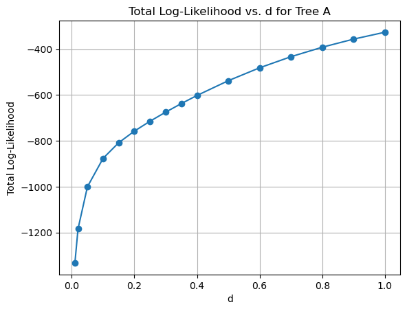

```python
# plot
plt.plot(d_list, log_likelihood_d, marker='o')
plt.xlabel('d')
plt.ylabel('Total Log-Likelihood')
plt.title('Total Log-Likelihood vs. d for Tree A')
plt.grid(True)
plt.show()
```

With the constructure of tree A, as the evolutionary distance d increases, the probability of observing the data also increases.

This phenomenon is due to the fact that the branch length d represents the evolutionary distance between sequences, indicating how many mutations and substitutions have occurred between the two sequences. A larger d value implies more mutations and substitutions between the sequences, thus resulting in a higher probability of observing the data under the given tree structure.